# COX PH models- Concepts and implementation

### Reading the data

```r
library("survival")
data(stanford2)
```

[output not shown]

```r
head(stanford2)
```

|  | id | time | status | age | t5 |
| --- | --- | --- | --- | --- | --- |
| 139 | 139 | 86 | 1 | 12 | 1.26 |
| 159 | 159 | 10 | 1 | 13 | 1.49 |
| 181 | 181 | 60 | 0 | 13 | NA |
| 119 | 119 | 1116 | 0 | 14 | 0.54 |
| 74 | 74 | 2006 | 0 | 15 | 1.26 |
| 120 | 120 | 1107 | 0 | 18 | 0.25 |

```r
NA
```

### Making a factor variable related to the Age > 40

```r
heart <- subset(stanford2, t5 != "NA")
Over40 <- ifelse(heart$age > 40,1,0)
heart <- cbind(heart, Over40)
heart$Over40 <- as.factor(heart$Over40)
```

### Making a factor variable related to T5 mismatchlevel 0,1,2

```r
len <- length(heart$t5)

misMatchLevel <- rep(0,len)

for (i in 1:len){

  if (heart$t5[i] > max(heart$t5)/3*2){

    misMatchLevel[i] <- 2

  }else if(heart$t5[i] > max(heart$t5)/3) {

    misMatchLevel[i] <- 1
  }

}

heart <- cbind(heart, misMatchLevel)

heart$misMatchLevel <- as.factor(heart$misMatchLevel)
```

### summary of the data

```r
summary(heart)
```

```
       id              time            status            age              t5        Over40
 Min.   :  1.00   Min.   :   0.5   Min.   :0.0000   Min.   :12.00   Min.   :0.000   0:58
 1st Qu.: 43.00   1st Qu.:  65.0   1st Qu.:0.0000   1st Qu.:36.00   1st Qu.:0.690   1:99
 Median : 83.00   Median : 468.0   Median :1.0000   Median :44.00   Median :1.040
 Mean   : 83.62   Mean   : 769.2   Mean   :0.6497   Mean   :41.73   Mean   :1.117
 3rd Qu.:123.00   3rd Qu.:1264.0   3rd Qu.:1.0000   3rd Qu.:49.00   3rd Qu.:1.460
 Max.   :174.00   Max.   :3695.0   Max.   :1.0000   Max.   :64.00   Max.   :3.050
 misMatchLevel
 0:76
 1:70
 2:11
```

### Cox model for the Over40 and the mismatch level

```r
cox.mod <- coxph(Surv(heart$time, heart$status)~heart$Over40 + heart$misMatchLevel)
summary(cox.mod)
```

```
Call:
coxph(formula = Surv(heart$time, heart$status) ~ heart$Over40 +
    heart$misMatchLevel)

  n= 157, number of events= 102

                       coef exp(coef) se(coef)     z Pr(>|z|)
heart$Over401        0.5452    1.7249   0.2191 2.488   0.0128 *
heart$misMatchLevel1 0.1275    1.1360   0.2083 0.612   0.5404
heart$misMatchLevel2 0.7548    2.1272   0.3896 1.937   0.0527 .
---
Signif. codes:  0 ‘***’ 0.001 ‘**’ 0.01 ‘*’ 0.05 ‘.’ 0.1 ‘ ’ 1

                     exp(coef) exp(-coef) lower .95 upper .95
heart$Over401            1.725     0.5797    1.1227     2.650
heart$misMatchLevel1     1.136     0.8803    0.7552     1.709
heart$misMatchLevel2     2.127     0.4701    0.9911     4.565

Concordance= 0.557  (se = 0.032 )
Likelihood ratio test= 9.31  on 3 df,   p=0.03
Wald test            = 9.38  on 3 df,   p=0.02
Score (logrank) test = 9.61  on 3 df,   p=0.02
```

At a given instant in time, someone who is over 40 is 1.7249 time as as likely to die as someone who is under 40 adjusting for mismatch level

### Cox model for the Over40

```r
cox.mod2 <- coxph(Surv(heart$time, heart$status)~ heart$Over40)
```

### Analysing model differences

```r
anova(cox.mod2, cox.mod, test = "LRT")
```

```
Analysis of Deviance Table
 Cox model: response is  Surv(heart$time, heart$status)
 Model 1: ~ heart$Over40
 Model 2: ~ heart$Over40 + heart$misMatchLevel
   loglik  Chisq Df P(>|Chi|)
1 -448.05
2 -446.44 3.2208  2    0.1998
```

When P chi is too high adding a coovarible is not statistically significant

### Cheking another model.

```r
cox.num <- coxph(Surv(heart$time, heart$status)~ heart$age +heart$t5)
summary(cox.num)
```

```
Call:
coxph(formula = Surv(heart$time, heart$status) ~ heart$age +
    heart$t5)

  n= 157, number of events= 102

             coef exp(coef) se(coef)     z Pr(>|z|)
heart$age 0.02961   1.03006  0.01136 2.608  0.00911 **
heart$t5  0.17041   1.18579  0.18326 0.930  0.35243
---
Signif. codes:  0 ‘***’ 0.001 ‘**’ 0.01 ‘*’ 0.05 ‘.’ 0.1 ‘ ’ 1

          exp(coef) exp(-coef) lower .95 upper .95
heart$age     1.030     0.9708     1.007     1.053
heart$t5      1.186     0.8433     0.828     1.698

Concordance= 0.59  (se = 0.034 )
Likelihood ratio test= 8.47  on 2 df,   p=0.01
Wald test            = 7.81  on 2 df,   p=0.02
Score (logrank) test = 7.87  on 2 df,   p=0.02
```

At a given instant in time, the probability of dying for someone who is 1 year older is 3% higher than someone who is 1 year younger adjusting for t5 score

### Checking the COX PH assumptions

#### Chekign linearity (For the model that used NUM X’s)

#### usign martingale residuales

```r
plot(predict(cox.num), residuals(cox.num, type="martingale"),
     xlab= "Fitted values", ylab ="Martingale residuals",
     main="residual Plot", las = 1)
### add a line ax y = residual = 0
abline(h=0)
```

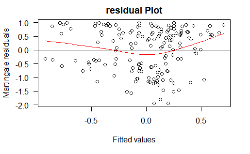

```r
# fir a smoother thru the points

lines(smooth.spline(predict(cox.num), residuals(cox.num, type="martingale")), col = "red")
```

```r
### and checking linearity using deviance residuals

plot(predict(cox.num), residuals(cox.num, type="deviance"))
abline(h=0)
```

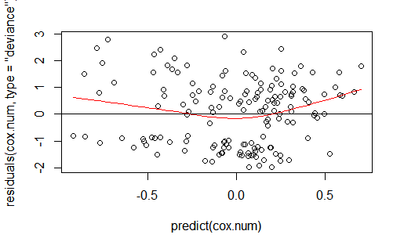

```r
lines(smooth.spline(predict(cox.num), residuals(cox.num, type="deviance")), col = "red")
```

appears to be a non-linear… we can address this categorizing the non linear variable, transforming the variable or any other method, stratifying the variable or making it time dependent

#### 2. Proportional Hazard

Ho: hazards are prop Ha: hazards are not prop will return test for each X,a nd for overall model

```r
cox.zph(cox.num)
```

```
          chisq df    p
heart$age  0.83  1 0.36
heart$t5   2.06  1 0.15
GLOBAL     2.77  2 0.25
```

[figure not shown]

```r
par(mfrow=c(2,1))
plot(cox.zph(cox.num))
```

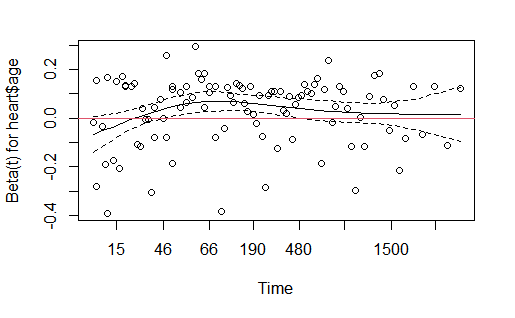

```r
par(mfrow=c(1,1))
plot(cox.zph(cox.num)[1])
abline(h=0, col=2)
```

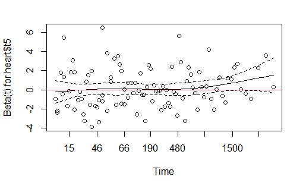

```r
par(mfrow=c(1,1))
plot(cox.zph(cox.num)[2])
abline(h=0, col=2)
```

The red line fit a lot the CI most of th time, so we can say that fits the proportional hazard model